# Cather Data Mapping Analysis

Sean

9/28/2022

## Cather Analysis - Location

### Initial mapping of letters by location written from

Conducting analyses based on where Cather was writing from requires an understanding of the distribution of locations involved. The map visual helps, but the summary statistics are even more revealing. New York is written from 1958 times, but the mean in terms of amount of times Cather wrote from a particular location is only 35, with the median being 2. Because of this disparity in terms of representation, analyses that rely on the text of the letters will need to sample the data rather than take the whole, uneven set.

```r
# read geo_json as such and into tibble
geo_json.df <- as_tibble(fromJSON("cather_geo_6_corrected.json"))
geo_json.df$features$properties$text_utf8 <- enc2utf8(geo_json.df$features$properties$text)

# summary stats
geo_json.df %>%
  group_by(geo_json.df$features$properties$origin_place) %>%
  count() %>%
  summary() # new york is the max, written from 1958 times!
```

```
##  geo_json.df$features$properties$origin_place       n
##  Length:89                                    Min.   :   1.00
##  Class :character                             1st Qu.:   1.00
##  Mode  :character                             Median :   2.00
##                                               Mean   :  35.11
##                                               3rd Qu.:   7.00
##                                               Max.   :1958.00
```

```r
# test mapping just letters by origin point
m <- leaflet(geo_json.df) %>% addTiles() %>%
  addMarkers(lng = geo_json.df$features$properties$lng,
             lat = geo_json.df$features$properties$lat,
             popup = geo_json.df$features$properties$letter)

# output maps
saveWidget(m, file="letter_distribution.html")
```

### Performing sentiment analysis on letter text and mapping to locations

Below, I explore using sentiment and text analysis methods to gain insight into differences in the text of the letters based on where Cather was writing from. In another document, I performed those analyses on the full dataset and then against a more evenly distributed sample. When using the full set, the uneven distribution certainly skewed results, as a classifier I ran to attempt to classify letters marked as being written from an unknown origin placed them all in New York, New York. Thus, I do not show those results below, but instead sample the data and explore how sentiment interacts with location, as well as attempt to classify the geographical origins of the unknown letters (assuming that the unknown places are represented by the known ones).

It should be noted that the sentiment analysis I perform is very crude and is only done to see if there are relationships worth exploring further. The thought is that if a crude approach shows interesting relationships starting to form, then it may be worth digging in.

```r
# let's sample the data to get an even split rather than have new york bias the set
five_or_over <- geo_json.df %>%
  group_by(geo_json.df$features$properties$origin_place) %>%
  count() %>%
  filter(n >= 5)

origin_places_five_plus <- five_or_over$`geo_json.df$features$properties$origin_place`

final_geo_data <- geo_json.df %>%
  subset(geo_json.df$features$properties$origin_place %in% origin_places_five_plus)

set.seed(1234)
final_geo_data <- final_geo_data %>%
  group_by(final_geo_data$features$properties$origin_place) %>%
  slice_sample(n = 5)

# Creating the document-term matrix for train data
sample_body_text <- final_geo_data$features$properties$text_utf8
doc.vec_train <- VectorSource(sample_body_text)
doc.corpus_train <- Corpus(doc.vec_train)
doc.corpus_train <- tm_map(doc.corpus_train , tolower)
doc.corpus_train <- tm_map(doc.corpus_train, removePunctuation)
doc.corpus_train <- tm_map(doc.corpus_train, removeNumbers)
doc.corpus_train <- tm_map(doc.corpus_train, removeWords, stopwords("english"))
doc.corpus_train <- tm_map(doc.corpus_train, stripWhitespace)

TDM_all <- TermDocumentMatrix(doc.corpus_train)
DTM_all <- DocumentTermMatrix(doc.corpus_train)
sample_DTM_all_sparse <- removeSparseTerms(DTM_all, .99) # sparseness can be modified

# sentiment analysis
sent <- analyzeSentiment(sample_DTM_all_sparse, language = "english")

# we're going to just select the Harvard-IV dictionary results ..
sent <- sent[,1:4]

#Organizing it as a dataframe
sent <- as.data.frame(sent)

# summarize statistics
summary(sent$SentimentGI)
```

```
##     Min.  1st Qu.   Median     Mean  3rd Qu.     Max.
## -0.16667  0.04295  0.06826  0.06978  0.10559  0.36364
```

```r
# Start by attaching to other data which has the company names
final <- bind_cols(final_geo_data[,1:2], sent)

# now lets get the positive sentiment
mean_sent_per_loc <- final %>% group_by(final_geo_data$features$properties$origin_place, final_geo_data$features$properties$lng, final_geo_data$features$properties$lat) %>%
  summarize(sent = mean(SentimentGI)) %>%
  arrange(desc(sent))

# now lets get the positive sentiment
mean_pos_sent_per_loc <- final %>% group_by(final_geo_data$features$properties$origin_place, final_geo_data$features$properties$lng, final_geo_data$features$properties$lat) %>%
  summarize(sent = mean(PositivityGI)) %>%
  arrange(desc(sent))

# now lets get the negative sentiment
mean_neg_sent_per_loc <- final %>% group_by(final_geo_data$features$properties$origin_place, final_geo_data$features$properties$lng, final_geo_data$features$properties$lat) %>%
  summarize(sent = mean(NegativityGI)) %>%
  arrange(desc(sent))

# summarize pos data
pos_sent <- data.frame(unclass(summary(mean_pos_sent_per_loc$sent)), check.names = FALSE, stringsAsFactors = FALSE)
low <- pos_sent[1,]
q1 <- pos_sent[2,]
mean <- pos_sent[4,]
q3 <- pos_sent[5,]
max <- pos_sent[6,]

limiter <- c(glue::glue('>{low} & <={q1}'), glue::glue('>{q1} & <={mean}'), glue::glue('>{mean} & <={q3}'), glue::glue('>{q3} & <={max}'))

# split pos sents and map
mean_pos_sent_per_loc.df <- mean_pos_sent_per_loc %>%
  mutate(pos.level = cut(sent, c(low, q1, mean, q3, max),
                                labels = limiter))

mean_pos_sent_per_loc.df <- split(mean_pos_sent_per_loc.df, mean_pos_sent_per_loc.df$pos.level)

pos <- leaflet() %>% addTiles()

names(mean_pos_sent_per_loc.df) %>%
  purrr::walk( function(df) {
    pos <<- pos %>%
      addMarkers(data=mean_pos_sent_per_loc.df[[df]],
                          lng=~`final_geo_data$features$properties$lng`, lat=~`final_geo_data$features$properties$lat`,
                          label=~paste0(`final_geo_data$features$properties$origin_place`, ": ", as.character(sent)),
                          popup=~as.character(sent),
                          group = df,
                          clusterOptions = markerClusterOptions(removeOutsideVisibleBounds = F),
                          labelOptions = labelOptions(noHide = F,
                                                       direction = 'auto'))
  })

pos <- pos %>%
  addLayersControl(
    overlayGroups = names(mean_pos_sent_per_loc.df),
    options = layersControlOptions(collapsed = FALSE)
  )

pos
```

[interactive chart not shown]

```r
# summarize neg data
neg_sent <- data.frame(unclass(summary(mean_neg_sent_per_loc$sent)), check.names = FALSE, stringsAsFactors = FALSE)
low <- neg_sent[1,]
q1 <- neg_sent[2,]
mean <- neg_sent[4,]
q3 <- neg_sent[5,]
max <- neg_sent[6,]

limiter <- c(glue::glue('>{low} & <={q1}'), glue::glue('>{q1} & <={mean}'), glue::glue('>{mean} & <={q3}'), glue::glue('>{q3} & <={max}'))

# split neg sents and map
mean_neg_sent_per_loc.df <- mean_neg_sent_per_loc %>%
  mutate(neg.level = cut(sent, c(low, q1, mean, q3, max),
                                labels = limiter))

mean_neg_sent_per_loc.df <- split(mean_neg_sent_per_loc.df, mean_neg_sent_per_loc.df$neg.level)

neg <- leaflet() %>% addTiles()

names(mean_neg_sent_per_loc.df) %>%
  purrr::walk( function(df) {
    neg <<- neg %>%
      addMarkers(data=mean_neg_sent_per_loc.df[[df]],
                          lng=~`final_geo_data$features$properties$lng`, lat=~`final_geo_data$features$properties$lat`,
                          label=~paste0(`final_geo_data$features$properties$origin_place`, ": ", as.character(sent)),
                          popup=~as.character(sent),
                          group = df,
                          clusterOptions = markerClusterOptions(removeOutsideVisibleBounds = F),
                          labelOptions = labelOptions(noHide = F,
                                                       direction = 'auto'))
  })

neg <- neg %>%
  addLayersControl(
    overlayGroups = names(mean_neg_sent_per_loc.df),
    options = layersControlOptions(collapsed = FALSE)
  )

neg
```

[interactive chart not shown]

```r
# summary stats for mean sent
sum_sent <- data.frame(unclass(summary(mean_sent_per_loc$sent)), check.names = FALSE, stringsAsFactors = FALSE)
low <- sum_sent[1,]
q1 <- sum_sent[2,]
mean <- sum_sent[4,]
q3 <- sum_sent[5,]
max <- sum_sent[6,]

limiter <- c(glue::glue('>{low} & <={q1}'), glue::glue('>{q1} & <={mean}'), glue::glue('>{mean} & <={q3}'), glue::glue('>{q3} & <={max}'))

# split sents and map
mean_sent_per_loc.df <- mean_sent_per_loc %>%
  mutate(sent.level = cut(sent, c(low, q1, mean, q3, max),
                                labels = limiter))

mean_sent_per_loc.df <- split(mean_sent_per_loc.df, mean_sent_per_loc.df$sent.level)

sents <- leaflet() %>% addTiles()

names(mean_sent_per_loc.df) %>%
  purrr::walk( function(df) {
    sents <<- sents %>%
      addMarkers(data=mean_sent_per_loc.df[[df]],
                          lng=~`final_geo_data$features$properties$lng`, lat=~`final_geo_data$features$properties$lat`,
                          label=~paste0(`final_geo_data$features$properties$origin_place`, ": ", as.character(sent)),
                          popup=~as.character(sent),
                          group = df,
                          clusterOptions = markerClusterOptions(removeOutsideVisibleBounds = F),
                          labelOptions = labelOptions(noHide = F,
                                                       direction = 'auto'))
  })

sents <- sents %>%
  addLayersControl(
    overlayGroups = names(mean_sent_per_loc.df),
    options = layersControlOptions(collapsed = FALSE)
  )

sents
```

[interactive chart not shown]

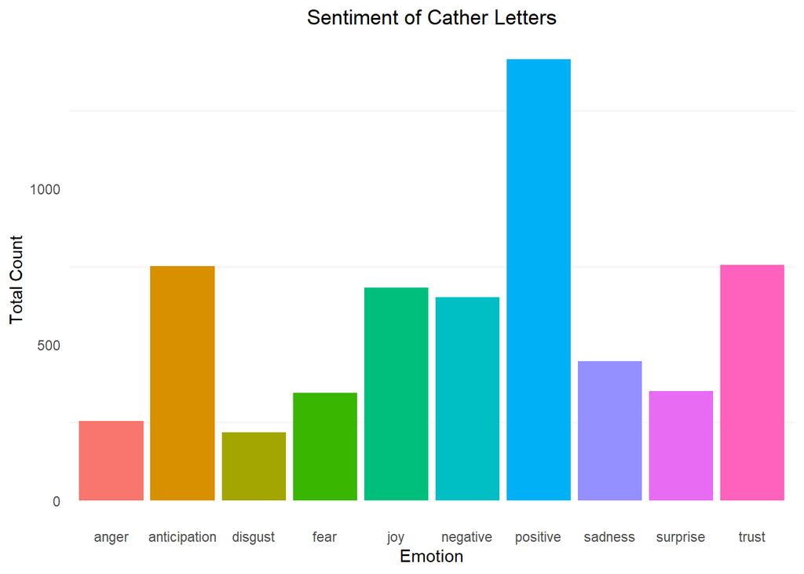

```r
# output maps
saveWidget(pos, file="pos_sent_per_loc.html")
saveWidget(neg, file="neg_sent_per_loc.html")
saveWidget(sents, file="sents_per_location.html")

# sanity check map sentiments by category
sent2 <- get_nrc_sentiment(sample_body_text)

# Let's look at the corpus as a whole again:
sent3 <- as.data.frame(colSums(sent2))
sent3 <- rownames_to_column(sent3)
colnames(sent3) <- c("emotion", "count")
ggplot(sent3, aes(x = emotion, y = count, fill = emotion)) + geom_bar(stat = "identity") + theme_minimal() + theme(legend.position="none", panel.grid.major = element_blank()) + labs( x = "Emotion", y = "Total Count") + ggtitle("Sentiment of Cather Letters") + theme(plot.title = element_text(hjust=0.5))
```

I’m not seeing anything terribly interesting from the crude sentiment analysis other than that Cather seems to skew more positive in her language (at least when considering non-sparsely used terms and an evenly distributed dataset). That said, I do think some of the visuals exploring degrees of positivity, negativity, and overall sentiment can lead to more targeted analysis of letters that Cather was writing from those locations identified. For instance, when selecting observations up to the first quartile and observations from the last quartile to the maximum (for negative, postive, and overall sentiment), we start to get a look at the outliers of the set, to see if letters written from the places represented do agree with those assessments - be they skewed more positive or negative.

### Performing classification and clustering to see if word features help categorize letters sent from unknown places

```r
# let's try to classify origin place of letters labeled unknown!

# convert train data to df
sample_df_dtm <- as.data.frame(as.matrix(sample_DTM_all_sparse))

# add dependent variable and metadata columns
sample_df_dtm$Origin_place <- final_geo_data$features$properties$origin_place
sample_df_dtm$Lng <- final_geo_data$features$properties$lng
sample_df_dtm$Lat <- final_geo_data$features$properties$lat
sample_df_dtm$Letter <- final_geo_data$features$properties$letter

# use just word features for now
sample_df_dtm_words <- sample_df_dtm[, 1:(ncol(sample_df_dtm)-4)]

# Splitting the dataset into the Training set and Test set
unknown.v <- which(sample_df_dtm$Origin_place == "unknown, triangle, bermuda")
sample_train <- sample_df_dtm_words[-unknown.v,]
class_f <- as.factor(sample_df_dtm[-unknown.v, "Origin_place"])

# test svm classification
set.seed(1234)
model_svm <- svm(sample_train, class_f)
pred_sample_train_svm <- predict(model_svm,sample_train)
train_pred <- as.data.frame(pred_sample_train_svm)
train_original_set <- final_geo_data[-unknown.v,]
train_pred$original <- train_original_set$features$properties$origin_place

# compute confusion matrix
svm_cm <- table(pred_sample_train_svm, class_f)
svm_cm.df <- as.data.frame(svm_cm)

# perform classification on test data
sample_test_data <- sample_df_dtm_words[unknown.v,]
pred_sample_test_svm <- predict(model_svm, sample_test_data)
test_pred <- as.data.frame(pred_sample_test_svm)
test_original_set <- final_geo_data[unknown.v,]
test_pred$original <- test_original_set$features$properties$origin_place
test_pred <- cbind(test_pred, test_original_set$features$properties)

# compute results
train_pred$correct <- if_else(train_pred$pred_sample_train_svm == train_pred$original, T, F)
train_pred %>%
  group_by(correct) %>%
  count() # 92% accuracy on the training set
```

```
## # A tibble: 2 x 2
## # Groups:   correct [2]
##   correct     n
##   <lgl>   <int>
## 1 FALSE      12
## 2 TRUE      143
```

```r
test_pred[,1:3] # predictions for unknown locations
```

```
##                 pred_sample_test_svm                   original letter
## 136      quebec city, quebec, canada unknown, triangle, bermuda   1886
## 137 lincoln, nebraska, united states unknown, triangle, bermuda   1786
## 138 lincoln, nebraska, united states unknown, triangle, bermuda   1808
## 139            at sea, voyage, world unknown, triangle, bermuda   1853
## 140 lincoln, nebraska, united states unknown, triangle, bermuda   1937
```

### Mapping works, people mentioned, places mentioned, and recipients to letter origin places

The next section of the analysis investigates the top 5 works, people, and places mentioned, as well as the top 5 recipients Cather wrote to and plots them on separate maps for users to compare and contrast who and what Cather wrote about most frequently from different places from which she wrote. At the moment, I don’t know what (if anything) is very interesting about these visualizations, but I think it could be interesting to choose different features to plot on these graphs to create different comparisons. Perhaps:

1. Where did Cather write about a particular set of works (her works, others’ works) and how do those places and works overlap?
2. What places in a specific area or region did Cather write about, and where was she writing about them from?
3. Where was Cather writing to her Cather relatives from? Where was she writing to professionals in her field(s) from?

It could be interesting to tie sentiment and other word feature analyses into these more segmented visualizations/analyses as well.

```r
## get top and bottom works, people, recipients, other places mentioned

# get top 5 referenced works, people, recipients, other places
works_count <- as_tibble(unlist(geo_json.df$features$properties$works_mentioned))
works_n <- works_count %>% count(value)
works_n$rel <- (works_n$n/sum(works_n$n)) * 100
least_ref_works <- works_n %>% subset(works_n$n == 1)
works_n <- works_n %>% top_n(5)

people_count <- as_tibble(unlist(geo_json.df$features$properties$people_mentioned))
people_n <- people_count %>% count(value)
people_n$rel <- (people_n$n/sum(people_n$n)) * 100
least_ref_people <- people_n %>% subset(people_n$n == 1)
people_n <- people_n %>% top_n(5)

places_count <- as_tibble(unlist(geo_json.df$features$properties$places_mentioned))
places_n <- places_count %>% count(value)
places_n$rel <- (places_n$n/sum(places_n$n)) * 100
least_ref_places <- places_n %>% subset(places_n$n == 1)
places_n <- places_n %>% top_n(5)

recip_count <- as_tibble(unlist(geo_json.df$features$properties$recipients))
recip_n <- recip_count %>% count(value)
recip_n$rel <- (recip_n$n/sum(recip_n$n)) * 100
least_ref_recip <- recip_n %>% subset(recip_n$n == 1)
recip_n <- recip_n %>% top_n(5)

# put works, people, and places into features in geo_json to be able to map as group layers
works_matches <- list()
places_matches <- list()
people_matches <- list()
recip_matches <- list()
for (i in 1:length(geo_json.df$type)) {
  # works
  works_found <- match(works_n$value, geo_json.df$features$properties$works_mentioned[[i]])
  works_matched_indices <- which(!is.na(works_found))
  works_matches[[i]] <- works_n$value[works_matched_indices]

  # places
  places_found <- match(places_n$value, geo_json.df$features$properties$places_mentioned[[i]])
  places_matched_indices <- which(!is.na(places_found))
  places_matches[[i]] <- places_n$value[places_matched_indices]

  # people
  people_found <- match(people_n$value, geo_json.df$features$properties$people_mentioned[[i]])
  people_matched_indices <- which(!is.na(people_found))
  people_matches[[i]] <- people_n$value[people_matched_indices]

  # recip
  recip_found <- match(recip_n$value, geo_json.df$features$properties$recipients[[i]])
  recip_matched_indices <- which(!is.na(recip_found))
  recip_matches[[i]] <- recip_n$value[recip_matched_indices]
}

# add to df
geo_json.df$works_in_top_5 <- works_matches
geo_json.df$places_in_top_5 <- places_matches
geo_json.df$people_in_top_5 <- people_matches
geo_json.df$recip_in_top_5 <- recip_matches

# subset works to remove those without any in the top 5
works_data.df <- tibble()
for (i in 1:length(geo_json.df$type)) {
  current_row <- geo_json.df[i,]
  works_list <- current_row$works_in_top_5
  len_works <- length(works_list[[1]])

  # define new temp df
  tmp.tbl <- tibble()
  work_there_column_name <- "has_work"

  if (len_works > 0) {
    tmp.tbl[1, works_n$value[1]] <- if_else(works_n$value[1] %in% current_row$works_in_top_5[[1]], 1, 0)
    tmp.tbl[1, works_n$value[2]] <- if_else(works_n$value[2] %in% current_row$works_in_top_5[[1]], 1, 0)
    tmp.tbl[1, works_n$value[3]] <- if_else(works_n$value[3] %in% current_row$works_in_top_5[[1]], 1, 0)
    tmp.tbl[1, works_n$value[4]] <- if_else(works_n$value[4] %in% current_row$works_in_top_5[[1]], 1, 0)
    tmp.tbl[1, works_n$value[5]] <- if_else(works_n$value[5] %in% current_row$works_in_top_5[[1]], 1, 0)
    tmp.tbl[1, work_there_column_name] <- 'Y'
  } else {
    tmp.tbl[1, works_n$value[1]] <- 0
    tmp.tbl[1, works_n$value[2]] <- 0
    tmp.tbl[1, works_n$value[3]] <- 0
    tmp.tbl[1, works_n$value[4]] <- 0
    tmp.tbl[1, works_n$value[5]] <- 0
    tmp.tbl[1, work_there_column_name] <- 'N'
  }

  works_data.df <- rbind(works_data.df, tmp.tbl)
}

works_data_analysis.df <- cbind(geo_json.df, works_data.df)

# subst for those with works
works_data_analysis_final.df <- works_data_analysis.df %>%
  subset(has_work == 'Y')

total_death <- sum(works_data_analysis_final.df$`death comes for the archbishop`)
total_mcculres <- sum(works_data_analysis_final.df$`mcclure's magazine`)
total_antonia <- sum(works_data_analysis_final.df$`my ántonia`)
total_one_of_ours <- sum(works_data_analysis_final.df$`one of ours`)
total_song_of_lark <- sum(works_data_analysis_final.df$`song of the lark, the`)

# group by coordinates
grouped_works <- works_data_analysis_final.df %>%
  group_by(works_data_analysis_final.df$features$geometry$coordinates, works_data_analysis_final.df$features$properties$origin_place) %>%
  summarize(
    sum_death_comes = sum(`death comes for the archbishop`),
    sum_mcclures = sum(`mcclure's magazine`),
    sum_antonia = sum(`my ántonia`),
    sum_one_of_ours = sum(`one of ours`),
    sum_song_of_lark = sum(`song of the lark, the`)
  )

grouped_works$rel_death_comes <- if_else(grouped_works$sum_death_comes > 0, (grouped_works$sum_death_comes / total_death) * 100, NULL)
grouped_works$rel_mcclures <- if_else(grouped_works$sum_mcclures > 0, (grouped_works$sum_mcclures / total_mcculres) * 100, NULL)
grouped_works$rel_antonia <- if_else(grouped_works$sum_antonia > 0, (grouped_works$sum_antonia / total_antonia) * 100, NULL)
grouped_works$rel_one_of_ours <- if_else(grouped_works$sum_one_of_ours > 0, (grouped_works$sum_one_of_ours / total_one_of_ours) * 100, NULL)
grouped_works$rel_song_of_lark <- if_else(grouped_works$sum_song_of_lark > 0, (grouped_works$sum_song_of_lark / total_song_of_lark) * 100, NULL)

# playing with scale
grouped_works$radius_death <- if_else(grouped_works$rel_death_comes^3 >= 100000, grouped_works$rel_death_comes^3, 100000)
grouped_works$radius_mcclures <- if_else(grouped_works$rel_mcclures^3 >= 100000, grouped_works$rel_mcclures^3, 100000)
grouped_works$radius_antonia <- if_else(grouped_works$rel_antonia^3 >= 100000, grouped_works$rel_antonia^3, 100000)
grouped_works$radius_one_of_ours <- if_else(grouped_works$rel_one_of_ours^3 >= 100000, grouped_works$rel_one_of_ours^3, 100000)
grouped_works$radius_song_of_lark <- if_else(grouped_works$rel_song_of_lark^3 >= 100000, grouped_works$rel_song_of_lark^3, 100000)

# pull out lat and lng
for (i in 1:length(grouped_works$sum_death_comes)) {
  grouped_works$lat[i] = grouped_works$`works_data_analysis_final.df$features$geometry$coordinates`[[i]][2]
  grouped_works$lng[i] = grouped_works$`works_data_analysis_final.df$features$geometry$coordinates`[[i]][1]
}

# Where does she not write to people that she writes to a lot from? Where does she write to 6 siblings from?
# places not represented? Who was she writing to/about? What other places was she mentioning?
# flavors of people: Top family member, top publisher, top other writer, top professional friends, deceased?
# 6:30 pm Eastern on Thursday
```

```r
# map above
l <- leaflet(grouped_works) %>% addTiles() %>%
  addCircles(lng = ~lng, lat = ~lat, weight = 1,
    radius = ~radius_death, fillColor = 'blue', color = 'blue', group = "death", label = paste0(grouped_works$`works_data_analysis_final.df$features$properties$origin_place`, ": ", as.character(grouped_works$rel_death_comes))) %>%
  addCircles(lng = ~lng, lat = ~lat, weight = 1,
    radius = ~radius_mcclures, fillColor = 'orange', color = 'orange', group = "mcclures", label = paste0(grouped_works$`works_data_analysis_final.df$features$properties$origin_place`, ": ", as.character(grouped_works$rel_mcclures))) %>%
  addCircles(lng = ~lng, lat = ~lat, weight = 1,
    radius = ~radius_antonia, fillColor = 'green', color = 'green', group = "antonia", label = paste0(grouped_works$`works_data_analysis_final.df$features$properties$origin_place`, ": ", as.character(grouped_works$rel_antonia))) %>%
  addCircles(lng = ~lng, lat = ~lat, weight = 1,
    radius = ~radius_one_of_ours, fillColor = 'red', color = 'red', group = "one of ours", label = paste0(grouped_works$`works_data_analysis_final.df$features$properties$origin_place`, ": ", as.character(grouped_works$rel_one_of_ours))) %>%
  addCircles(lng = ~lng, lat = ~lat, weight = 1,
    radius = ~radius_song_of_lark, fillColor = 'purple', color = 'purple', group = "song of lark", label = paste0(grouped_works$`works_data_analysis_final.df$features$properties$origin_place`, ": ", as.character(grouped_works$rel_song_of_lark))) %>%
  addLayersControl(
    overlayGroups = c("death", "mcclures", "antonia", "one of ours", "song of lark"),
    options = layersControlOptions(collapsed = FALSE))
l
```

[interactive chart not shown]

```r
saveWidget(l, file="works.html")
```

```r
# subset people to remove those without any in the top 5
people_data.df <- tibble()
for (i in 1:length(geo_json.df$type)) {
  current_row <- geo_json.df[i,]
  people_list <- current_row$people_in_top_5
  len_people <- length(people_list[[1]])

  # define new temp df
  tmp.tbl <- tibble()
  people_there_column_name <- "has_people"

  if (len_people > 0) {
    tmp.tbl[1, people_n$value[1]] <- if_else(people_n$value[1] %in% current_row$people_in_top_5[[1]], 1, 0)
    tmp.tbl[1, people_n$value[2]] <- if_else(people_n$value[2] %in% current_row$people_in_top_5[[1]], 1, 0)
    tmp.tbl[1, people_n$value[3]] <- if_else(people_n$value[3] %in% current_row$people_in_top_5[[1]], 1, 0)
    tmp.tbl[1, people_n$value[4]] <- if_else(people_n$value[4] %in% current_row$people_in_top_5[[1]], 1, 0)
    tmp.tbl[1, people_n$value[5]] <- if_else(people_n$value[5] %in% current_row$people_in_top_5[[1]], 1, 0)
    tmp.tbl[1, people_there_column_name] <- 'Y'
  } else {
    tmp.tbl[1, people_n$value[1]] <- 0
    tmp.tbl[1, people_n$value[2]] <- 0
    tmp.tbl[1, people_n$value[3]] <- 0
    tmp.tbl[1, people_n$value[4]] <- 0
    tmp.tbl[1, people_n$value[5]] <- 0
    tmp.tbl[1, people_there_column_name] <- 'N'
  }

  people_data.df <- rbind(people_data.df, tmp.tbl)
}

people_data_analysis.df <- cbind(geo_json.df, people_data.df)

# subst for those with works
people_data_analysis_final.df <- people_data_analysis.df %>%
  subset(has_people == 'Y')

grouped_people <- people_data_analysis_final.df %>%
  group_by(people_data_analysis_final.df$features$geometry$coordinates, people_data_analysis_final.df$features$properties$origin_place) %>%
  summarize(
    sum_cather_boak_mary_virginia = sum(`Cather Boak Mary Virginia Jennie`),
    sum_cather_roscoe = sum(`Cather Roscoe`),
    sum_greenslet_ferris = sum(`Greenslet Ferris`),
    sum_alfred_knopf = sum(`Knopf Alfred A.`),
    sum_lewis_edith = sum(`Lewis Edith`)
  )

# get totals for rel freq
total_cather_boak <- sum(people_data_analysis_final.df$`Cather Boak Mary Virginia Jennie`)
total_cather_roscoe <- sum(people_data_analysis_final.df$`Cather Roscoe`)
total_greenslet <- sum(people_data_analysis_final.df$`Greenslet Ferris`)
total_knopf <- sum(people_data_analysis_final.df$`Knopf Alfred A.`)
total_lewis_edith <- sum(people_data_analysis_final.df$`Lewis Edith`)

# calc rel freqs
grouped_people$rel_cather_boak <- if_else(grouped_people$sum_cather_boak_mary_virginia > 0, (grouped_people$sum_cather_boak_mary_virginia / total_cather_boak) * 100, NULL)
grouped_people$rel_cather_roscoe <- if_else(grouped_people$sum_cather_roscoe > 0, (grouped_people$sum_cather_roscoe / total_cather_roscoe) * 100, NULL)
grouped_people$rel_greenslet <- if_else(grouped_people$sum_greenslet_ferris > 0, (grouped_people$sum_greenslet_ferris / total_greenslet) * 100, NULL)
grouped_people$rel_knopf <- if_else(grouped_people$sum_alfred_knopf > 0, (grouped_people$sum_alfred_knopf / total_knopf) * 100, NULL)
grouped_people$rel_lewis_edith <- if_else(grouped_people$sum_lewis_edith > 0, (grouped_people$sum_lewis_edith / total_lewis_edith) * 100, NULL)

# play with scale
grouped_people$radius_cather_boak <- if_else(grouped_people$rel_cather_boak^3 >= 100000, grouped_people$rel_cather_boak^3, 100000)
grouped_people$radius_cather_roscoe <- if_else(grouped_people$rel_cather_roscoe^3 >= 100000, grouped_people$rel_cather_roscoe^3, 100000)
grouped_people$radius_greenslet <- if_else(grouped_people$rel_greenslet^3 >= 100000, grouped_people$rel_greenslet^3, 100000)
grouped_people$radius_knopf <- if_else(grouped_people$rel_knopf^3 >= 100000, grouped_people$rel_knopf^3, 100000)
grouped_people$radius_lewis_edith <- if_else(grouped_people$rel_lewis_edith^3 >= 100000, grouped_people$rel_lewis_edith^3, 100000)

# pull out lat and lng
for (i in 1:length(grouped_people$sum_cather_boak_mary_virginia)) {
  grouped_people$lat[i] = grouped_people$`people_data_analysis_final.df$features$geometry$coordinates`[[i]][2]
  grouped_people$lng[i] = grouped_people$`people_data_analysis_final.df$features$geometry$coordinates`[[i]][1]
}

k <- leaflet(grouped_people) %>% addTiles() %>%
  addCircles(lng = ~lng, lat = ~lat, weight = 1,
    radius = ~radius_cather_boak, fillColor = 'blue', color = 'blue', group = "cather boak", label = paste0(grouped_people$`people_data_analysis_final.df$features$properties$origin_place`, ": ", as.character(grouped_people$rel_cather_boak))) %>%
  addCircles(lng = ~lng, lat = ~lat, weight = 1,
    radius = ~radius_cather_roscoe, fillColor = 'orange', color = 'orange', group = "cather roscoe", label = paste0(grouped_people$`people_data_analysis_final.df$features$properties$origin_place`, ": ", as.character(grouped_people$rel_cather_roscoe))) %>%
  addCircles(lng = ~lng, lat = ~lat, weight = 1,
    radius = ~radius_greenslet, fillColor = 'green', color = 'green', group = "greenslet ferris", label = paste0(grouped_people$`people_data_analysis_final.df$features$properties$origin_place`, ": ", as.character(grouped_people$rel_greenslet))) %>%
  addCircles(lng = ~lng, lat = ~lat, weight = 1,
    radius = ~radius_knopf, fillColor = 'red', color = 'red', group = "knopf alfred", label = paste0(grouped_people$`people_data_analysis_final.df$features$properties$origin_place`, ": ", as.character(grouped_people$rel_knopf))) %>%
  addCircles(lng = ~lng, lat = ~lat, weight = 1,
    radius = ~radius_lewis_edith, fillColor = 'purple', color = 'purple', group = "lewis edith", label = paste0(grouped_people$`people_data_analysis_final.df$features$properties$origin_place`, ": ", as.character(grouped_people$rel_lewis_edith))) %>%
  addLayersControl(
    overlayGroups = c("cather boak", "cather roscoe", "greenslet ferris", "knopf alfred", "lewis edith"),
    options = layersControlOptions(collapsed = FALSE))

k
```

[interactive chart not shown]

```r
saveWidget(k, 'people_mentioned.html')
```

```r
# subset places to remove those without any in the top 5
places_data.df <- tibble()
for (i in 1:length(geo_json.df$type)) {
  current_row <- geo_json.df[i,]
  places_list <- current_row$places_in_top_5
  len_places <- length(places_list[[1]])

  # define new temp df
  tmp.tbl <- tibble()
  places_there_column_name <- "has_places"

  if (len_places > 0) {
    tmp.tbl[1, places_n$value[1]] <- if_else(places_n$value[1] %in% current_row$places_in_top_5[[1]], 1, 0)
    tmp.tbl[1, places_n$value[2]] <- if_else(places_n$value[2] %in% current_row$places_in_top_5[[1]], 1, 0)
    tmp.tbl[1, places_n$value[3]] <- if_else(places_n$value[3] %in% current_row$places_in_top_5[[1]], 1, 0)
    tmp.tbl[1, places_n$value[4]] <- if_else(places_n$value[4] %in% current_row$places_in_top_5[[1]], 1, 0)
    tmp.tbl[1, places_n$value[5]] <- if_else(places_n$value[5] %in% current_row$places_in_top_5[[1]], 1, 0)
    tmp.tbl[1, places_there_column_name] <- 'Y'
  } else {
    tmp.tbl[1, places_n$value[1]] <- 0
    tmp.tbl[1, places_n$value[2]] <- 0
    tmp.tbl[1, places_n$value[3]] <- 0
    tmp.tbl[1, places_n$value[4]] <- 0
    tmp.tbl[1, places_n$value[5]] <- 0
    tmp.tbl[1, places_there_column_name] <- 'N'
  }

  places_data.df <- rbind(places_data.df, tmp.tbl)
}

places_data_analysis.df <- cbind(geo_json.df, places_data.df)

# subst for those with works
places_data_analysis_final.df <- places_data_analysis.df %>%
  subset(has_places == 'Y')

grouped_places <- places_data_analysis_final.df %>%
  group_by(places_data_analysis_final.df$features$geometry$coordinates, places_data_analysis_final.df$features$properties$origin_place) %>%
  summarize(
    sum_boston = sum(`boston, massachusetts, united states`),
    sum_chicago = sum(`chicago, illinois, united states`),
    sum_nebraska = sum(`nebraska, united states`),
    sum_new_york = sum(`new york, new york, united states`),
    sum_red_cloud = sum(`red cloud, nebraska, united states`)
  )

# get totals for rel freq
total_boston <- sum(places_data_analysis_final.df$`boston, massachusetts, united states`)
total_chicago <- sum(places_data_analysis_final.df$`chicago, illinois, united states`)
total_nebraska <- sum(places_data_analysis_final.df$`nebraska, united states`)
total_new_york <- sum(places_data_analysis_final.df$`new york, new york, united states`)
total_red_cloud <- sum(places_data_analysis_final.df$`red cloud, nebraska, united states`)

# calc rel freqs
grouped_places$rel_boston <- if_else(grouped_places$sum_boston > 0, (grouped_places$sum_boston / total_boston) * 100, NULL)
grouped_places$rel_chicago <- if_else(grouped_places$sum_chicago > 0, (grouped_places$sum_chicago / total_chicago) * 100, NULL)
grouped_places$rel_nebraska <- if_else(grouped_places$sum_nebraska > 0, (grouped_places$sum_nebraska / total_nebraska) * 100, NULL)
grouped_places$rel_new_york <- if_else(grouped_places$sum_new_york > 0, (grouped_places$sum_new_york / total_new_york) * 100, NULL)
grouped_places$rel_red_cloud <- if_else(grouped_places$sum_red_cloud > 0, (grouped_places$sum_red_cloud / total_red_cloud) * 100, NULL)

# play with scale
grouped_places$radius_boston <- if_else(grouped_places$rel_boston^3 >= 100000, grouped_places$rel_boston^3, 100000)
grouped_places$radius_chicago <- if_else(grouped_places$rel_chicago^3 >= 100000, grouped_places$rel_chicago^3, 100000)
grouped_places$radius_nebraska <- if_else(grouped_places$rel_nebraska^3 >= 100000, grouped_places$rel_nebraska^3, 100000)
grouped_places$radius_new_york <- if_else(grouped_places$rel_new_york^3 >= 100000, grouped_places$rel_new_york^3, 100000)
grouped_places$radius_red_cloud <- if_else(grouped_places$rel_red_cloud^3 >= 100000, grouped_places$rel_red_cloud^3, 100000)

# pull out lat and lng
for (i in 1:length(grouped_places$sum_boston)) {
  grouped_places$lat[i] = grouped_places$`places_data_analysis_final.df$features$geometry$coordinates`[[i]][2]
  grouped_places$lng[i] = grouped_places$`places_data_analysis_final.df$features$geometry$coordinates`[[i]][1]
}

o <- leaflet(grouped_places) %>% addTiles() %>%
  addCircles(lng = ~lng, lat = ~lat, weight = 1,
    radius = ~radius_boston, fillColor = 'blue', color = 'blue', group = "boston", label = paste0(grouped_places$`places_data_analysis_final.df$features$properties$origin_place`, ": ", as.character(grouped_places$rel_boston))) %>%
  addCircles(lng = ~lng, lat = ~lat, weight = 1,
    radius = ~radius_chicago, fillColor = 'orange', color = 'orange', group = "chicago", label = paste0(grouped_places$`places_data_analysis_final.df$features$properties$origin_place`, ": ", as.character(grouped_places$rel_chicago))) %>%
  addCircles(lng = ~lng, lat = ~lat, weight = 1,
    radius = ~radius_nebraska, fillColor = 'green', color = 'green', group = "nebraska", label = paste0(grouped_places$`places_data_analysis_final.df$features$properties$origin_place`, ": ", as.character(grouped_places$rel_nebraska))) %>%
  addCircles(lng = ~lng, lat = ~lat, weight = 1,
    radius = ~radius_new_york, fillColor = 'red', color = 'red', group = "new york", label = paste0(grouped_places$`places_data_analysis_final.df$features$properties$origin_place`, ": ", as.character(grouped_places$rel_new_york))) %>%
  addCircles(lng = ~lng, lat = ~lat, weight = 1,
    radius = ~radius_red_cloud, fillColor = 'purple', color = 'purple', group = "red cloud", label = paste0(grouped_places$`places_data_analysis_final.df$features$properties$origin_place`, ": ", as.character(grouped_places$rel_red_cloud))) %>%
  addLayersControl(
    overlayGroups = c("boston", "chicago", "nebraska", "new york", "red cloud"),
    options = layersControlOptions(collapsed = FALSE))

o
```

[interactive chart not shown]

```r
saveWidget(o, 'places_mentioned.html')
```

```r
# subset recip to remove those without any in the top 5
recip_data.df <- tibble()
for (i in 1:length(geo_json.df$type)) {
  current_row <- geo_json.df[i,]
  recip_list <- current_row$recip_in_top_5
  len_recip <- length(recip_list[[1]])

  # define new temp df
  tmp.tbl <- tibble()
  recip_there_column_name <- "has_recip"

  if (len_recip > 0) {
    tmp.tbl[1, recip_n$value[1]] <- if_else(recip_n$value[1] %in% current_row$recip_in_top_5[[1]], 1, 0)
    tmp.tbl[1, recip_n$value[2]] <- if_else(recip_n$value[2] %in% current_row$recip_in_top_5[[1]], 1, 0)
    tmp.tbl[1, recip_n$value[3]] <- if_else(recip_n$value[3] %in% current_row$recip_in_top_5[[1]], 1, 0)
    tmp.tbl[1, recip_n$value[4]] <- if_else(recip_n$value[4] %in% current_row$recip_in_top_5[[1]], 1, 0)
    tmp.tbl[1, recip_n$value[5]] <- if_else(recip_n$value[5] %in% current_row$recip_in_top_5[[1]], 1, 0)
    tmp.tbl[1, recip_there_column_name] <- 'Y'
  } else {
    tmp.tbl[1, recip_n$value[1]] <- 0
    tmp.tbl[1, recip_n$value[2]] <- 0
    tmp.tbl[1, recip_n$value[3]] <- 0
    tmp.tbl[1, recip_n$value[4]] <- 0
    tmp.tbl[1, recip_n$value[5]] <- 0
    tmp.tbl[1, recip_there_column_name] <- 'N'
  }

  recip_data.df <- rbind(recip_data.df, tmp.tbl)
}

recip_data_analysis.df <- cbind(geo_json.df, recip_data.df)

# subst for those with works
recip_data_analysis_final.df <- recip_data_analysis.df %>%
  subset(has_recip == 'Y')

grouped_recip <- recip_data_analysis_final.df %>%
  group_by(recip_data_analysis_final.df$features$geometry$coordinates, recip_data_analysis_final.df$features$properties$origin_place) %>%
  summarize(
    sum_akins_zoe = sum(`Akins Zoë`),
    sum_cather_roscoe = sum(`Cather Roscoe`),
    sum_greenslet_ferris = sum(`Greenslet Ferris`),
    sum_alfred_knopf = sum(`Knopf Alfred A.`),
    sum_sherwood = sum(`Sherwood Miner Carrie`)
  )

# get totals for rel freq
total_r_akins_zoe <- sum(recip_data_analysis_final.df$`Akins Zoë`)
total_r_cather_roscoe <- sum(recip_data_analysis_final.df$`Cather Roscoe`)
total_r_greenslet <- sum(recip_data_analysis_final.df$`Greenslet Ferris`)
total_r_knopf <- sum(recip_data_analysis_final.df$`Knopf Alfred A.`)
total_r_sherwood <- sum(recip_data_analysis_final.df$`Sherwood Miner Carrie`)

# calc rel freqs
grouped_recip$rel_akins_zoe <- if_else(grouped_recip$sum_akins_zoe > 0, (grouped_recip$sum_akins_zoe / total_r_akins_zoe) * 100, NULL)
grouped_recip$rel_cather_roscoe <- if_else(grouped_recip$sum_cather_roscoe > 0, (grouped_recip$sum_cather_roscoe / total_r_cather_roscoe) * 100, NULL)
grouped_recip$rel_greenslet <- if_else(grouped_recip$sum_greenslet_ferris > 0, (grouped_recip$sum_greenslet_ferris / total_r_greenslet) * 100, NULL)
grouped_recip$rel_knopf <- if_else(grouped_recip$sum_alfred_knopf > 0, (grouped_recip$sum_alfred_knopf / total_r_knopf) * 100, NULL)
grouped_recip$rel_sherwood <- if_else(grouped_recip$sum_sherwood > 0, (grouped_recip$sum_sherwood / total_r_sherwood) * 100, NULL)

# play with scale
grouped_recip$radius_akins <- if_else(grouped_recip$rel_akins_zoe^3 >= 100000, grouped_recip$rel_akins_zoe^3, 100000)
grouped_recip$radius_roscoe <- if_else(grouped_recip$rel_cather_roscoe^3 >= 100000, grouped_recip$rel_cather_roscoe^3, 100000)
grouped_recip$radius_greenslet <- if_else(grouped_recip$rel_greenslet^3 >= 100000, grouped_recip$rel_greenslet^3, 100000)
grouped_recip$radius_knopf <- if_else(grouped_recip$rel_knopf^3 >= 100000, grouped_recip$rel_knopf^3, 100000)
grouped_recip$radius_sherwood <- if_else(grouped_recip$rel_sherwood^3 >= 100000, grouped_recip$rel_sherwood^3, 100000)

# pull out lat and lng
for (i in 1:length(grouped_recip$sum_akins_zoe)) {
  grouped_recip$lat[i] = grouped_recip$`recip_data_analysis_final.df$features$geometry$coordinates`[[i]][2]
  grouped_recip$lng[i] = grouped_recip$`recip_data_analysis_final.df$features$geometry$coordinates`[[i]][1]
}

p <- leaflet(grouped_recip) %>% addTiles() %>%
  addCircles(lng = ~lng, lat = ~lat, weight = 1,
    radius = ~radius_akins, fillColor = 'blue', color = 'blue', group = "akins zoe", label = paste0(grouped_recip$`recip_data_analysis_final.df$features$properties$origin_place`, ": ", as.character(grouped_recip$rel_akins_zoe))) %>%
  addCircles(lng = ~lng, lat = ~lat, weight = 1,
    radius = ~radius_roscoe, fillColor = 'orange', color = 'orange', group = "cather roscoe", label = paste0(grouped_recip$`recip_data_analysis_final.df$features$properties$origin_place`, ": ", as.character(grouped_recip$rel_cather_roscoe))) %>%
  addCircles(lng = ~lng, lat = ~lat, weight = 1,
    radius = ~radius_greenslet, fillColor = 'green', color = 'green', group = "greenslet ferris", label = paste0(grouped_people$`people_data_analysis_final.df$features$properties$origin_place`, ": ", as.character(grouped_recip$rel_greenslet))) %>%
  addCircles(lng = ~lng, lat = ~lat, weight = 1,
    radius = ~radius_knopf, fillColor = 'red', color = 'red', group = "knopf alfred", label = paste0(grouped_recip$`recip_data_analysis_final.df$features$properties$origin_place`, ": ", as.character(grouped_recip$rel_knopf))) %>%
  addCircles(lng = ~lng, lat = ~lat, weight = 1,
    radius = ~radius_sherwood, fillColor = 'purple', color = 'purple', group = "sherwood miner carrie", label = paste0(grouped_recip$`recip_data_analysis_final.df$features$properties$origin_place`, ": ", as.character(grouped_recip$rel_sherwood))) %>%
  addLayersControl(
    overlayGroups = c("akins zoe", "cather roscoe", "greenslet ferris", "knopf alfred", "sherwood miner carrie"),
    options = layersControlOptions(collapsed = FALSE))

p
```

[interactive chart not shown]

```r
saveWidget(o, 'recipients.html')
```